# Investigating Socioeconomic Disparities in Longevity for the 1910 Cohort

Casey Breen (caseybreen@berkeley.edu)

2023-03-19

## Summary

In this vignette, we explore the association between socioeconomic indicators and longevity for the 1910 cohort of males using the CenSoc-DMF data. Ordinary Least Squares (OLS) Regression on age of death is an easy and effective way to analyze the CenSoc mortality data.

This vignette is written in the style of the “tidyverse.” There are many other ways to analyze data in R, including base R and `data.table`.

## Getting Started

- `HISTID`
- `EDUCD`
- `RACE`
- `OWNERSHP`
- `INCWAGE`

```r
## Library Packages
library(data.table)
library(ipumsr)
library(tidyverse)
library(gridExtra)
library(cowplot)
library(broom)

## Read in CenSoc-DMF file
censoc_dmf <- fread("/data/josh/CenSoc/censoc_data/censoc_linked_to_census/v2.1/censoc_dmf_v2.1_linked.csv")

## Restrict to cohort of 1910
censoc_dmf <- censoc_dmf %>%
  filter(byear == 1910)
```

## Data Preparation

IPUMS variables often have value labels, which are text that corresponds to numeric codes (e.g., the `SEX` variable has value labels: 1 = “Male”, 2 = “Female”).

The `IPUMSR` package includes helpful functions for assigning values labels (see the [ipumsr website](http://tech.popdata.org/ipumsr/index.html) for more information and tutorials). In this vignette, for simplicity, we will manually code our value labels.

Note that `incwage` only measures salaried or wage earners (non-agricultural/business owners) and is topcoded at 5001; all incomes over $5000 ($93,000 today) are added to the 5001 value. Values listed as “999998” and “999999” represent missing values. Additionally, several `incwage` values are 0. For this vignette, we will ignore those values, but the implications are important to consider for your own research. In addition to the aforementioned non-wage earners, “0” could also represent those outside of the labor force due to injury or school.

```r
## Restrict to men with a non-missing value of income and education
censoc_dmf <- censoc_dmf %>%
  filter(INCWAGE > 0 & INCWAGE < 5002) %>%
  filter((EDUCD > 0 & EDUC < 999)) ## Education is topcoded at 999

## Recode EDUCD (education, detailed) variable to years of education
censoc_dmf <- censoc_dmf %>%
  mutate(educ_yrs = case_when(
  EDUCD == 999 ~ 0,
  EDUCD == 14 ~ 2,
  EDUCD == 15 ~ 3,
  EDUCD == 16 ~ 4,
  EDUCD == 17 ~ 5,
  EDUCD == 22 ~ 6,
  EDUCD == 23 ~ 7,
  EDUCD == 25 ~ 8,
  EDUCD == 26 ~ 9,
  EDUCD == 30 ~ 10,
  EDUCD == 40 ~ 11,
  EDUCD == 50 ~ 12,
  EDUCD == 60 ~ 13,
  EDUCD == 70 ~ 14,
  EDUCD == 80 ~ 15,
  EDUCD == 90 ~ 16,
  TRUE ~ 17
))

## Recode RACE var to string
censoc_dmf <- censoc_dmf %>%
  mutate(race_string = case_when(
    RACE == 1 & HISPAN == 0 ~ "White",
    RACE == 2 & HISPAN == 0 ~ "Black",
    TRUE ~ "Other"
  ))

## Recode OWNERSHP variable to string
censoc_dmf <- censoc_dmf %>%
  mutate(ownership_string = case_when(
    OWNERSHP == 1 ~ "Owner",
    OWNERSHP == 2 ~ "Renter"))
```

## Exploratory Data Analysis

Exploratory data analysis is an important part of the modeling process and can help us understand the main characteristics of the data and their relationship with our dependent variable, age at death. Here, we will briefly explore some associations between our independent and dependent variables.

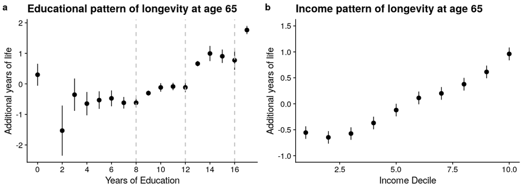

```r
## Additional years of life expectancy by education
educ_df <- censoc_dmf %>%
  group_by(educ_yrs) %>%
  summarize(death_age_educ = mean(death_age), sd = sd(death_age) * (1/sqrt(n())) ) %>%
  mutate(add_yrs_life = death_age_educ - mean(death_age_educ)) %>%
  ungroup()

## Education Plot
educ_plot <- ggplot(data = educ_df, mapping = aes(x = educ_yrs, y = add_yrs_life)) +
  geom_pointrange(aes(ymin = add_yrs_life - 1.96*sd, ymax = add_yrs_life + 1.96*sd)) +
  theme_cowplot() +
  scale_x_continuous(breaks = seq(0, 23, 2)) +
  geom_vline(xintercept = c(8, 12, 16), lwd = .7, lty = 2, color = "grey") +
  labs(title = "Educational pattern of longevity at age 65",
       x = "Years of Education",
       y = "Additional years of life")

## Additional years of life expectancy by income decile
income_df <- censoc_dmf %>%
  filter(INCWAGE < 5500 & INCWAGE > 0) %>%
  filter(!is.na(INCWAGE)) %>%
  mutate(wage_decile = ntile(INCWAGE,10)) %>%
  group_by(wage_decile) %>%
  summarize(death_age_decile = mean(death_age), sd = sd(death_age) * (1/sqrt(n())) ) %>%
  mutate(add_yrs_life = death_age_decile - mean(death_age_decile))

## Income Plot
income_plot <- ggplot(data = income_df, mapping = aes(x = wage_decile, y = add_yrs_life)) +
  geom_pointrange(aes(ymin = add_yrs_life - 1.96*sd, ymax = add_yrs_life + 1.96*sd)) +
  labs(title = "Income pattern of longevity at age 65",
       x = "Income Decile",
       y = "Additional years of life") +
  theme_cowplot() +
  ylim(-1, 1.5)

## Display Plots
plot_grid(educ_plot, income_plot, labels = "auto")
```

```r
## Library Packages
library(data.table)
library(ipumsr)
library(tidyverse)
library(gridExtra)
library(cowplot)
library(broom)

## Read in CenSoc-DMF file
## Restrict to conservative matches (fewer false matches)
censoc_dmf <- fread("/data/josh/CenSoc/censoc_data/censoc_linked_to_census/v2.1/censoc_dmf_v2.1_linked.csv") %>%
  filter(link_abe_exact_conservative == 1)

## Restrict to cohort of 1910
censoc_dmf <- censoc_dmf %>%
  filter(byear == 1910)
```

## Data Preparation

IPUMS variables often have value labels, which are text that corresponds to numeric codes (e.g., the `SEX` variable has value labels: 1 = “Male”, 2 = “Female”).

The `IPUMSR` package includes helpful functions for assigning values labels (see the [ipumsr website](http://tech.popdata.org/ipumsr/index.html) for more information and tutorials). In this vignette, for simplicity, we will manually code our value labels.

Note that `incwage` only measures salaried or wage earners (non-agricultural/business owners) and is topcoded at $5001; all reported wage and salary incomes over $5000 are coded to the 5001 value. Values listed as “999998” and “999999” represent missing values. Additionally, several `incwage` values are 0. For this vignette, we will ignore those values, but the implications are important to consider for your own research. In addition to the aforementioned non-wage earners, “0” could also represent those outside of the labor force due to injury or school.

```r
## Restrict to men with a non-missing value of income and education
censoc_dmf <- censoc_dmf %>%
  filter(INCWAGE > 0 & INCWAGE < 5002) %>%
  filter((EDUCD > 0 & EDUC < 999)) ## Education is topcoded at 999

## Recode EDUCD (education, detailed) variable to years of education
censoc_dmf <- censoc_dmf %>%
  mutate(educ_yrs = case_when(
   EDUCD == 2 ~ 0,
   EDUCD == 12 ~ 0,
   EDUCD == 14 ~ 1,
   EDUCD == 15 ~ 2,
   EDUCD == 16 ~ 3,
   EDUCD == 17 ~ 4,
   EDUCD == 22 ~ 5,
   EDUCD == 23 ~ 6,
   EDUCD == 25 ~ 7,
   EDUCD == 26 ~ 8,
   EDUCD == 30 ~ 9,
   EDUCD == 40 ~ 10,
   EDUCD == 50 ~ 11,
   EDUCD == 60 ~ 12,
   EDUCD == 70 ~ 13,
   EDUCD == 80 ~ 14,
   EDUCD == 90 ~ 15,
   EDUCD == 100 ~ 16,
   EDUCD == 110 ~ 17,
   EDUCD == 111 ~ 17,
   EDUCD == 112 ~ 17,
   EDUCD == 113 ~ 17
))

## Recode RACE var to string
censoc_dmf <- censoc_dmf %>%
  mutate(race_string = case_when(
    RACE == 1 & HISPAN == 0 ~ "White",
    RACE == 2 & HISPAN == 0 ~ "Black",
    TRUE ~ "Other"
  ))

## Recode OWNERSHP variable to string
censoc_dmf <- censoc_dmf %>%
  mutate(ownership_string = case_when(
    OWNERSHP == 1 ~ "Owner",
    OWNERSHP == 2 ~ "Renter"))
```

## Exploratory Data Analysis

Exploratory data analysis is an important part of the modeling process and can help us understand the main characteristics of the data and their relationship with our dependent variable, age at death. Here, we will briefly explore some associations between our independent and dependent variables.

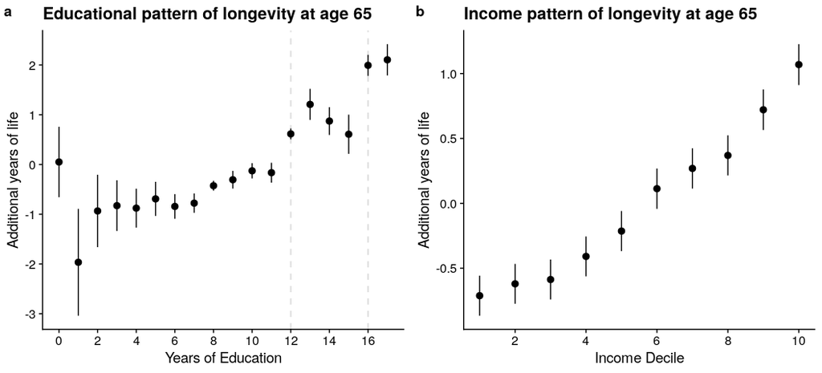

```r
## Additional years of life expectancy by education
educ_df <- censoc_dmf %>%
  group_by(educ_yrs) %>%
  summarize(death_age_educ = mean(death_age), sd = sd(death_age) * (1/sqrt(n())) ) %>%
  mutate(add_yrs_life = death_age_educ - mean(death_age_educ)) %>%
  ungroup()

## Education Plot
educ_plot <- ggplot(data = educ_df, mapping = aes(x = educ_yrs, y = add_yrs_life)) +
  geom_vline(xintercept = c(12, 16), lwd = .7, lty = 2, color = "grey", alpha = .5) +
  geom_pointrange(aes(ymin = add_yrs_life - 1.96*sd, ymax = add_yrs_life + 1.96*sd)) +
  theme_cowplot() +
  scale_x_continuous(breaks = seq(0, 23, 2)) +
  labs(title = "Educational pattern of longevity at age 65",
       x = "Years of Education",
       y = "Additional years of life")

## Additional years of life expectancy by income decile
income_df <- censoc_dmf %>%
  filter(INCWAGE < 5500 & INCWAGE > 0) %>%
  filter(!is.na(INCWAGE)) %>%
  mutate(wage_decile = ntile(INCWAGE,10)) %>%
  group_by(wage_decile) %>%
  summarize(death_age_decile = mean(death_age), sd = sd(death_age) * (1/sqrt(n())) ) %>%
  mutate(add_yrs_life = death_age_decile - mean(death_age_decile))

## Income Plot
income_plot <- ggplot(data = income_df, mapping = aes(x = wage_decile, y = add_yrs_life)) +
  geom_pointrange(aes(ymin = add_yrs_life - 1.96*sd, ymax = add_yrs_life + 1.96*sd)) +
  labs(title = "Income pattern of longevity at age 65",
       x = "Income Decile",
       y = "Additional years of life") +
  theme_cowplot() +
  scale_x_continuous(breaks = seq(0, 10, 2))

## Display Plots
plot_grid(educ_plot, income_plot, labels = "auto")
```

## OLS Regression on Age of Death

$$Age\_at\_death = birth\_year\_dummy +
covariates\_of\_interest$$

In this case, we are only looking at the cohort of 1910, so we do not need to include a fixed effect term for year of birth.

```r
## Prepare for Regression
censoc_dmf <- censoc_dmf %>%
  mutate(race_string = as.factor(race_string)) %>%
  mutate(race_string = relevel(race_string, ref = "White"))

## Plot Model
model <- lm(death_age ~ INCWAGE + educ_yrs + ownership_string + race_string,
            data = censoc_dmf,
            weights = weight)

## View model summary
summary(model)
```

```
##
## Call:
## lm(formula = death_age ~ INCWAGE + educ_yrs + ownership_string +
##     race_string, data = censoc_dmf, weights = weight)
##
## Weighted Residuals:
##    Min     1Q Median     3Q    Max
## -32.89 -12.04   0.36  12.23  36.93
##
## Coefficients:
##                          Estimate Std. Error t value Pr(>|t|)
## (Intercept)             7.591e+01  9.473e-02 801.262  < 2e-16 ***
## INCWAGE                 3.850e-04  3.914e-05   9.837  < 2e-16 ***
## educ_yrs                1.945e-01  8.906e-03  21.836  < 2e-16 ***
## ownership_stringRenter -2.365e-01  5.323e-02  -4.444 8.85e-06 ***
## race_stringBlack        5.612e-03  1.371e-01   0.041    0.967
## race_stringOther        1.273e+00  1.841e-01   6.918 4.60e-12 ***
## ---
## Signif. codes:  0 '***' 0.001 '**' 0.01 '*' 0.05 '.' 0.1 ' ' 1
##
## Residual standard error: 15.05 on 98263 degrees of freedom
##   (4730 observations deleted due to missingness)
## Multiple R-squared:  0.009818,   Adjusted R-squared:  0.009768
## F-statistic: 194.9 on 5 and 98263 DF,  p-value: < 2.2e-16
```

## Visualizing Model Coefficients

The `broom` package takes the results from the model we ran in R and conveniently formats it as a data.frame representation. Using this package, we both extract and plot our coefficients and associated confidence intervals.

For a more comprehensive review of working with model-based graphics in `R`, we recommend Kieran Healy’s [Data Visualization: A Practical Introduction](https://socviz.co/).

[figure not shown]

```r
## Construct a data.frame of the results of our statistical model
tidy.model <- tidy(model, conf.int = T)
tidy.model <- subset(tidy.model, !term %in% "(Intercept)")

## Plot Regression Coefficients
ggplot(tidy.model, mapping = aes(x = term, y = estimate, ymax = conf.high, ymin = conf.low)) +
  geom_pointrange() +
  coord_flip() +
  theme_cowplot() +
  labs(y = "OLS Estimate")
```

The `broom` package takes the results from the model we ran in R and conveniently formats it as a data.frame representation. Using this package, we both extract and plot our coefficients and associated confidence intervals.

For a more comprehensive review of working with model-based graphics in `R`, we recommend Kieran Healy’s [Data Visualization: A Practical Introduction](https://socviz.co/).

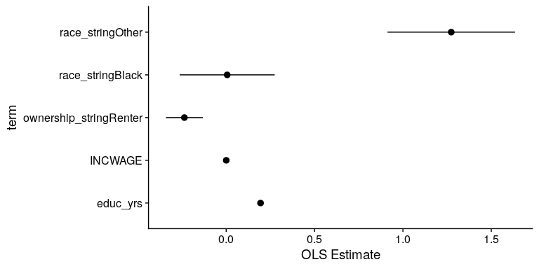

```r
## Construct a data.frame of the results of our statistical model
tidy.model <- tidy(model, conf.int = T)
tidy.model <- subset(tidy.model, !term %in% "(Intercept)")

## Plot Regression Coefficients
ggplot(tidy.model, mapping = aes(x = term, y = estimate, ymax = conf.high, ymin = conf.low)) +
  geom_pointrange() +
  coord_flip() +
  theme_cowplot() +
  labs(y = "OLS Estimate")
```